# model comparison

Maddee Wiggins (FlowWest)

2026-03-03

## Comparison of Results

*The following compares models and results for the FlowWest Chinook and Steelhead models to the FERC 2004 report that analyzed the same data.*

### FlowWest Models:

**Goal**: model that reflects the significance of cover, substrate, depth, and velocity on steelhead presence and absence

- binary logistic regression
- response variable - presence/absence
- mixed effect framework
- retains full ecological covariate set

### FERC 2004 Model

Report: SP F-10 3A FINAL REPORT DISTRIBUTION AND HABITAT USE OF JUVENILE STEELHEAD AND OTHER FISHES OF THE LOWER FEATHER RIVER

**Goal:** A habitat-use inference model to guide management and restoration planning

- Binary logistic regression with fixed-effect
- no random effects
- AIC-based variable selection
- model captures habitat quality

### Differences

| Variable | FERC 2004 Report Findings | Chinook Model | Steelhead Model |
| --- | --- | --- | --- |
| **Depth** | Steelhead associated with shallower margins; Chinook vary by size class | Positive and highly significant effect on presence | Negative and significant effect on presence |
| **Velocity** | Steelhead avoid higher velocities; prefer lower velocity microhabitats | Strong negative effect on presence | Strong negative effect on presence (larger magnitude than Chinook) |
| **Substrate** | Gravel/cobble more frequently used than fine substrates | Cobble and boulder not significant once hydraulics included | Substrate not significant once hydraulics included |
| **In-stream Cover** | Positive association with instream cover; Large cover important for some size classes | Large woody not significant; small woody positive but moderate | Small woody positive and significant |
| **Overhanging Vegetation** | Large cover important for some size classes | Strong positive and significant effect | Strong positive and significant effect |
| **Aquatic Vegetation** | Positive association in low-velocity areas | Negative and significant | Positive and significant |
| **Undercut Bank** | positive association reported | Positive, not significant | Positive, not significant |
| **Spawning (Redd) Signal** | Not included in models | Redd total significant; redd presence marginal | Redd presence strong; redd total significant |
| **Temporal Structure** | Seasonal patterns described but not modeled hierarchically | Strong month variance component | Weak month variance component |

### Model Evaluation

*How are models evaluated for performance? Are they?*

- **FlowWest models**
  - Goal: Are certain habitat variables significantly associated with fish presence? How well does the model predict presence and how robust is the prediction
  - Evaluation: AUC, confusion matrix, p-values
- **2004 FERC report**
  - Goal: Are certain habitat variables significantly associated with fish presence?
  - Evaluation: P-values, AIC
- **Favrot et al.****,**
  - Goal: Is this the best-supported explanatory model for habitat selection?
  - Evaluation: AIC-based model selection with mixed-effects RSF, residual diagnostics, confidence intervals/odds ratios, and Bayesian credible intervals
- Beakes et al., 2012
  - Goal: compare two statistical approaches for modeling juvenile Chinook salmon habitat - first model is a traditional composite suitability index style aggregated univariate model, second model is a multivariate GLM using AIC model selection
  - Evaluation: Cohen’s Kappa, optimized threshold, percent correctly classified, sensitivity, specificity, AUC

    | Metric | Beakes Model G | FW Steelhead | FW Chinook |
    | --- | --- | --- | --- |
    | AUC | 0.649 | 0.913 | 0.907 |
    | Kappa | 0.203 | 0.31 | 0.23 |
    | Sensitivity | 37.5% | 27% | 14.1% |
    | Specificity | 83.6% | 99.5% | 99.8% |

- *Kappa - a measure of all possible outcomes of presence or absence that are predicted correctly, after accounting for chance predictions*
- *Sensitivity - Measures how well the model detects fish when they are present*
- *Specificity - Measures how well the model avoids false alarms.*
- *AUC - Measures how well a model can distinguish between presence and absence across all possible probability thresholds, not just one cutoff*

### Figures Comparing FlowWest Chinook and Steelhead Models

**Conallin et al. 2014 - Figure 5**

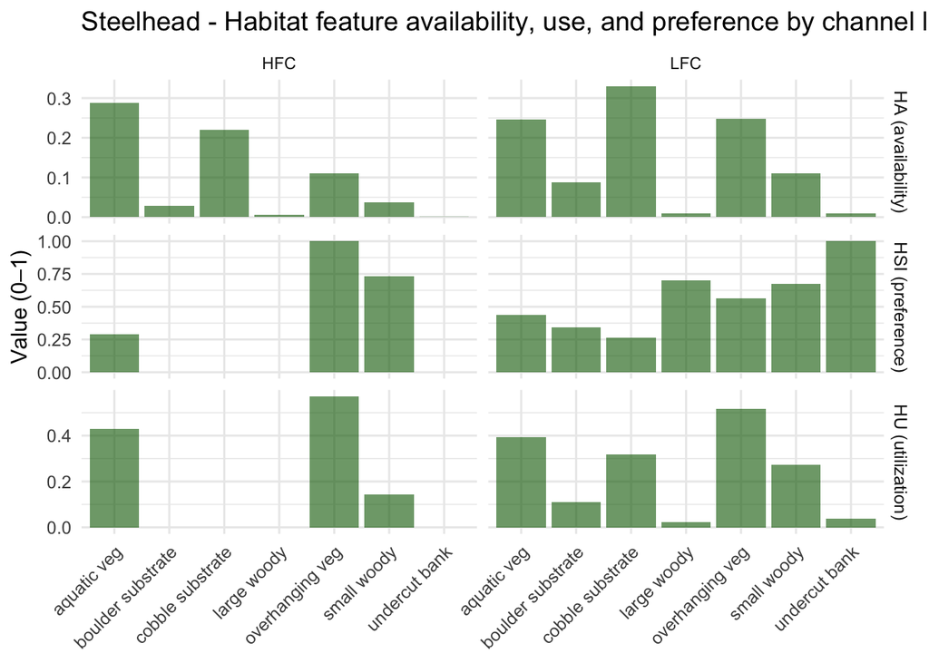

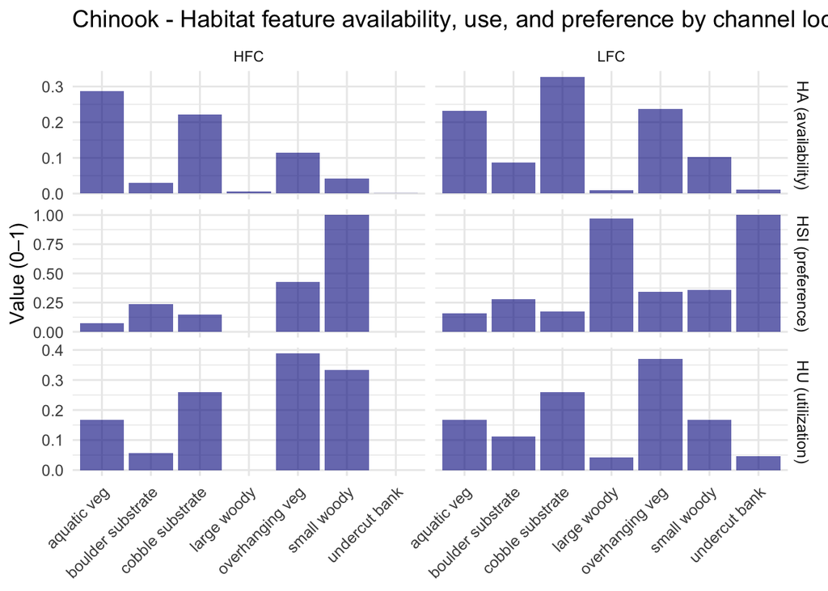